# DATA 606 Fall 2018 - Final Exam

Calvin Wong

# Part I

Please put the answers for Part I next to the question number (2pts each):

1. B
2. D
3. D
4. D
5. B
6. D

7a. Describe the two distributions (2pts).

7b. Explain why the means of these two distributions are similar but the standard deviations are not (2 pts).

7c. What is the statistical principal that describes this phenomenon (2 pts)?

The Central Limit Theorem is the principal that describes this. It states that properly normalized sums tends to follow a normal distribution.

# Part II

Consider the four datasets, each with two columns (x and y), provided below. Be sure to replace the `NA` with your answer for each part (e.g. assign the mean of `x` for `data1` to the `data1.x.mean` variable). When you Knit your answer document, a table will be generated with all the answers.

```r
options(digits=2)
data1 <- data.frame(x=c(10,8,13,9,11,14,6,4,12,7,5),
                    y=c(8.04,6.95,7.58,8.81,8.33,9.96,7.24,4.26,10.84,4.82,5.68))
data2 <- data.frame(x=c(10,8,13,9,11,14,6,4,12,7,5),
                    y=c(9.14,8.14,8.74,8.77,9.26,8.1,6.13,3.1,9.13,7.26,4.74))
data3 <- data.frame(x=c(10,8,13,9,11,14,6,4,12,7,5),
                    y=c(7.46,6.77,12.74,7.11,7.81,8.84,6.08,5.39,8.15,6.42,5.73))
data4 <- data.frame(x=c(8,8,8,8,8,8,8,19,8,8,8),
                    y=c(6.58,5.76,7.71,8.84,8.47,7.04,5.25,12.5,5.56,7.91,6.89))
```

For each column, calculate (to two decimal places):

#### a. The mean (for x and y separately; 1 pt).

```r
data1.x.mean <- mean(data1$x)
data1.y.mean <- mean(data1$y)
data2.x.mean <- mean(data2$x)
data2.y.mean <- mean(data2$y)
data3.x.mean <- mean(data3$x)
data3.y.mean <- mean(data3$y)
data4.x.mean <- mean(data4$x)
data4.y.mean <- mean(data4$y)
```

#### b. The median (for x and y separately; 1 pt).

```r
data1.x.median <- median(data1$x)
data1.y.median <- median(data1$y)
data2.x.median <- median(data2$x)
data2.y.median <- median(data2$y)
data3.x.median <- median(data3$x)
data3.y.median <- median(data3$y)
data4.x.median <- median(data4$x)
data4.y.median <- median(data4$y)
```

#### c. The standard deviation (for x and y separately; 1 pt).

```r
data1.x.sd <- sd(data1$x)
data1.y.sd <- sd(data1$y)
data2.x.sd <- sd(data2$x)
data2.y.sd <- sd(data2$y)
data3.x.sd <- sd(data3$x)
data3.y.sd <- sd(data3$y)
data4.x.sd <- sd(data4$x)
data4.y.sd <- sd(data4$y)
```

#### For each x and y pair, calculate (also to two decimal places; 1 pt):

#### d. The correlation (1 pt).

```r
data1.correlation <- cor(data1$x, data1$y)
data2.correlation <- cor(data2$x, data2$y)
data3.correlation <- cor(data3$x, data3$y)
data4.correlation <- cor(data4$x, data4$y)
```

#### e. Linear regression equation (2 pts).

```r
data1_lm <- lm(y ~ x, data1)
data2_lm <- lm(y ~ x, data2)
data3_lm <- lm(y ~ x, data3)
data4_lm <- lm(y ~ x, data4)

data1.slope <- data1_lm$coefficients[2]
data2.slope <- data2_lm$coefficients[2]
data3.slope <- data3_lm$coefficients[2]
data4.slope <- data4_lm$coefficients[2]

data1.intercept <- data1_lm$coefficients[1]
data2.intercept <- data2_lm$coefficients[1]
data3.intercept <- data3_lm$coefficients[1]
data4.intercept <- data4_lm$coefficients[1]
```

#### f. R-Squared (2 pts).

```r
data1.rsquared <- data1.correlation ^2
data2.rsquared <- data2.correlation ^2
data3.rsquared <- data3.correlation ^2
data4.rsquared <- data4.correlation ^2
```

|  | Data 1 x | Data 1 y | Data 2 x | Data 2 y | Data 3 x | Data 3 y | Data 4 x | Data 4 y |
| --- | --- | --- | --- | --- | --- | --- | --- | --- |
| Mean | 9.00 | 7.50 | 9.00 | 7.50 | 9.00 | 7.50 | 9.00 | 7.50 |
| Median | 9.00 | 7.58 | 9.00 | 8.14 | 9.00 | 7.11 | 8.00 | 7.04 |
| SD | 3.32 | 2.03 | 3.32 | 2.03 | 3.32 | 2.03 | 3.32 | 2.03 |
| r | 0.82 |  | 0.82 |  | 0.82 |  | 0.82 |  |
| Intercept | 3.00 |  | 3.00 |  | 3.00 |  | 3.00 |  |
| Slope | 0.50 |  | 0.50 |  | 0.50 |  | 0.50 |  |
| R-Squared | 0.67 |  | 0.67 |  | 0.67 |  | 0.67 |  |

#### g. For each pair, is it appropriate to estimate a linear regression model? Why or why not? Be specific as to why for each pair and include appropriate plots! (4 pts)

Data 1

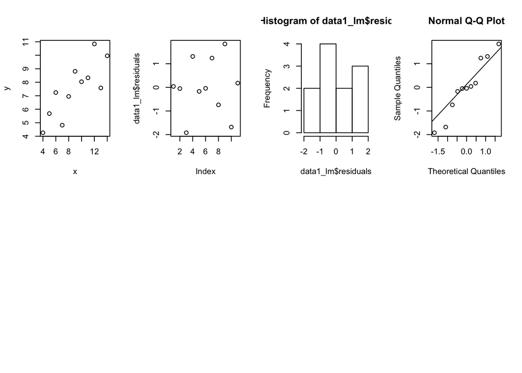

```r
par(mfrow=c(2,4))
plot(data1)
plot(data1_lm$residuals)
hist(data1_lm$residuals)
qqnorm(data1_lm$residuals)
qqline(data1_lm$residuals)
```

Data 2

No, the data does not show a linear trend on the scatterplot. The residuals histogram does not follow a normal distribution as well. Therefore, a simple linear model is inadequate for modeling these data.

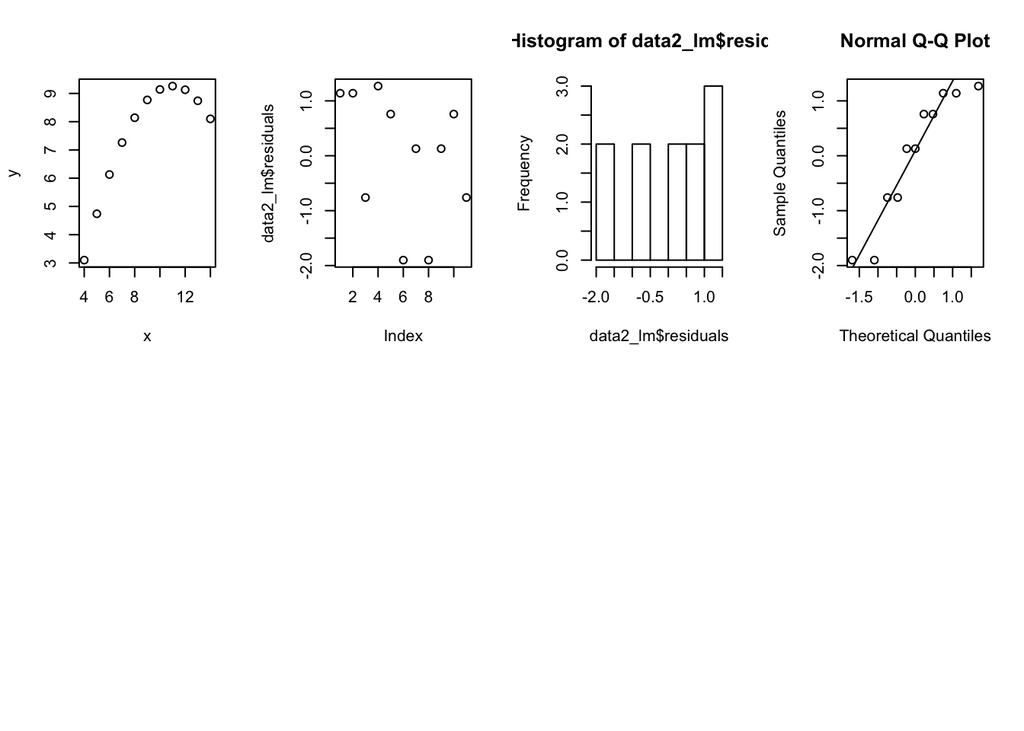

```r
par(mfrow=c(2,4))
plot(data2)
plot(data2_lm$residuals)
hist(data2_lm$residuals)
qqnorm(data2_lm$residuals)
qqline(data2_lm$residuals)
```

Data 3

No, one of the point is relatively distant from the rest of the data points. This is reflected in the residuals as well. A simple linear model is inadequate for modeling these types data.

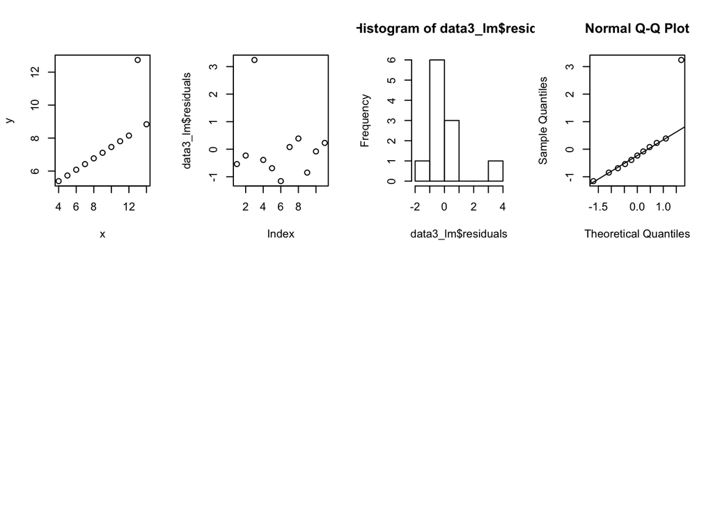

```r
par(mfrow=c(2,4))
plot(data3)
plot(data3_lm$residuals)
hist(data3_lm$residuals)
qqnorm(data3_lm$residuals)
qqline(data3_lm$residuals)
```

Data 4

No, the plot does not indicate any linearity at all. The residuals do not follow a normal distribution as well. A simple linear model is inadequate for modeling these data.

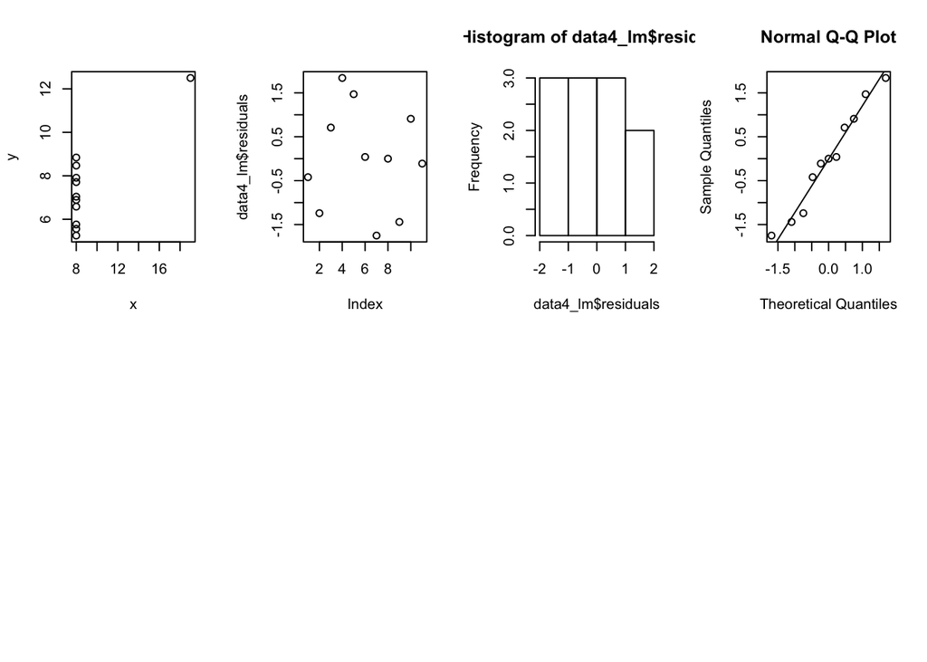

```r
par(mfrow=c(2,4))
plot(data4)
plot(data4_lm$residuals)
hist(data4_lm$residuals)
qqnorm(data4_lm$residuals)
qqline(data4_lm$residuals)
```